# Observabilité PostgreSQL

La configuration des logs qui change tout

Alain Lesage

Devoxx FR

23 avril 2026

## Questions

## Qui-suis-je ?

- *Administrateur* de Bases de Données – **DBA**
- Expert **PostgreSQL**
- Consultant chez **DALIBO**
- *Vibe Codeur* Go

[figure not shown]

## Point important

Version **officielle** de PostgreSQL

[postgresql.org](https://www.postgresql.org/download/)

[figure not shown]

## Menu

- Observabilité, coût et complexité
- Configuration des logs
- Exploitation des logs
- Démo

## Observabilité PostgreSQL

[figure not shown]

### Observabilité ?

> L’observabilité est une mesure de la capacité à déduire l’état interne d’un système à partir de la connaissance de ses sorties externes.

### Observabilité ?

> L’observabilité est une mesure de la capacité à déduire l’état interne d’un système à partir de la **connaissance** de ses sorties externes.

### Observabilité ?

> L’observabilité est une mesure de la capacité à **déduire** l’état interne d’un système à partir de la **connaissance** de ses sorties externes.

### Quels symptômes ?

- Performance
  - *“Ce traitement dure 10 minutes au lieu de 15 secondes”*
- Disponibilité
  - *“Mon instance n’accepte plus de nouvelle connexion”*
- Mesures
  - *“On constate un pic CPU / Le FS est plein à 90%”*

### Quels Problèmes ?

- **Causes Racines**
  - Quelles **requêtes** posent problème ?
  - Quelles **applications** posent problème ?
  - Quelles **connexions** posent problème ?
  - Quels **utilisateurs** posent problème ?

### Outils

- vues internes
- extension `pg_stat_statements`
- tableaux de bord

### Vues internes

- ~40 vues de statistiques
  - `pg_stat_activity`, `pg_stat_io`, `pg_stat_user_table`
  - sessions, réplication, tables, index, IO…
- ~40 vues système
  - `pg_locks`, `pg_wait_events`, `pg_aios`, `pg_tables`…
- peu de granularité, compteurs cumulés

### Extension/vue `pg_stat_statements`

- Granularité **par requête** normalisée :
  - nombre d’appels, temps, lignes, blocs, fichiers temporaires…
- compteurs cumulés, pas d’historique
- Pas installée par défaut
- Nécessite un redémarrage (`shared_preload_libraries`)

### Tableaux de bord

- Permettent l’historicisation et la visualisation
- Spécialisés PostgreSQL
  - temBoard, PoWA…
  - pgAnalyze
- Plateformes généralistes
  - Datadog, New Relic…
  - Grafana + Prometheus
- **connaissance**

[figure not shown]

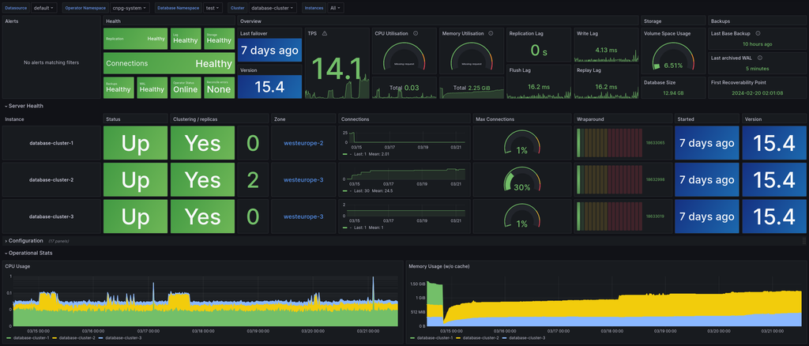

### Tableaux de bord – les limites

- Chers et complexes
  - déployer, configurer, maintenir
- Angles morts
  - quelle requête provoque un verrou ?
  - quelle erreur de connexion revient 157 fois ?
- **déduction**

### Un super outil d’observabilité

- Connexions/déconnexions
- Verrous et attentes
- Requêtes lentes, fréquentes, avec paramètres et plan
- Fichiers temporaires
- Activité en écriture
- Toutes les erreurs applicatives
- Adaptable sans redémarrage
- **sans agent**
- **horodaté nativement**

### …les logs :)

[figure not shown]

## Configuration des logs

[figure not shown]

### Langue

```
lc_messages = C
```

```
FATAL: le rôle « app_user » n'existe pas
```

```
FATAL: role "app_user" does not exist
```

- **pas** par défaut

### Format

- format `jsonl`
- `csv` aussi possible

```
logging_collector = on
log_destination = jsonlog
```

```json
{"timestamp":"2026-01-01 09:10:11.176 CET",
 "pid":198716,
 "user":"app_user","dbname":"appdb",
 "error_severity":"LOG",
 "message":"duration: 3118.394 ms  execute: SELECT …",
 "application_name":"backend-api",
 "backend_type":"client backend",
 "query_id":0}
```

- **pas** par défaut

### Préfixe

```
log_line_prefix = '%t [%p] %e: db=%d,user=%u,app=%a,client=%h '
```

```
2026-01-01 09:10:11.176 CET [198716] LOG:
    duration: 3118.394 ms  execute: SELECT …
```

```
2026-01-01 09:10:11 CET [198716] 00000: db=appdb,user=app_user,
    app=backend-api,client=10.0.170.81 LOG:
    duration: 3118.394 ms  execute: SELECT …
```

- **pas** par défaut

### Connexions

- lien avec `max_connections`

```
log_connections = on
```

```
…: user=app_user,db=appdb,app=[unknown],client=10.0.170.82 LOG:
    connection authorized: user=app_user database=appdb
    application_name=backend-api
```

- **pas** par défaut

### Déconnexions

- durée des sessions

```
log_disconnections = on
```

```
…: user=app_user,db=appdb,app=backend-api,client=10.0.170.82 LOG:
    disconnection: session time: 0:00:03.418
    user=app_user database=appdb host=10.0.170.82
```

- **pas** par défaut

### Verrous

```
log_lock_waits = on # deadlock_timeout = 1s (défaut)
```

```
…[1074]: db=app_db,user=batch,app=batch_job,client=172.28.0.20 LOG:
    duration: 12045.334 ms  statement:
    UPDATE lock_test SET value = value + 50 WHERE id = 1;
…[1075]: db=app_db,user=batch,app=batch_job,client=172.28.0.20 LOG:
    process 1075 still waiting for ShareLock on transaction 863
    after 1005.176 ms
…[1075]: DETAIL: Process holding the lock: 1074. Wait queue: 1075.
…[1075]: STATEMENT:
    UPDATE lock_test SET value = value + 100 WHERE id = 1;
```

- **pas** par défaut

### Fichier temporaires

- lien avec `work_mem`

```
log_temp_files = 0 # 100kB, 1MB…
```

```
…: db=appdb,user=analytics,app=reporting,client=10.0.171.10 LOG:
    temporary file: path "base/pgsql_tmp/pgsql_tmp1849757.0",
    size 2756640
…: db=appdb,user=analytics,app=reporting,client=10.0.171.10 STATEMENT:
    SELECT * FROM large_transactions
    ORDER BY amount DESC, created_at, transaction_id
    LIMIT 10000;
```

- **pas** par défaut

### Autovacuum

- maintenance automatique Postgres
- critique pour les écritures

```
log_autovacuum_min_duration = 0 # 100ms, 1s
```

```
…: LOG:  automatic vacuum of table "appdb.public.app_lock":
    index scans: 1
    pages: 0 removed, 12600 remain, 0 skipped due to pins
    tuples: 74 removed, 1464 remain, 172 are dead but not yet removable
…: LOG:  automatic aggressive vacuum to prevent wraparound
    of table "appdb.public.enq_pli": index scans: 0
    pages: 0 removed, 7135 remain, 1 scanned (0.01% of total)
    tuples: 0 removed, 244187 remain
    new relfrozenxid: 820687730, which is 200001140 XIDs
    ahead of previous value
```

- **pas** par défaut

### Requêtes

```
log_min_duration_statement = 0 # 100ms, 1s
```

```
…: db=appdb,user=app_user,app=backend-api,client=10.0.170.83 LOG:
    duration: 3118.394 ms  execute dbdpg_p33048_42:
    SELECT DISTINCT vrp.valeur
    FROM referentiel_param vrp
    WHERE vrp.code = $1
```

- **pas** par défaut

### Auto EXPLAIN

```
session_preload_libraries = 'auto_explain'
auto_explain.log_min_duration = '1s'
auto_explain.log_analyze = on
auto_explain.sample_rate = 0.1 # 10% des requêtes
```

```
…: db=appdb,user=app_user,app=backend-api,client=10.0.170.83 LOG:
    duration: 3118.394 ms  plan:
    Query Text: SELECT * FROM orders WHERE status = $1
    Seq Scan on orders (cost=0.00..1250.00 rows=5000 width=64)
      (actual time=0.015..3118.100 rows=4832 loops=1)
      Filter: (status = 'pending')
      Rows Removed by Filter: 95168
```

- **pas** par défaut

### Checkpoints

```
log_checkpoints = on
```

```
…: [107-1] user=,db= LOG:  checkpoint starting: time
…: [108-1] user=,db= LOG:  checkpoint complete: wrote 2425 buffers (0.3%);
    0 transaction log file(s) added, 0 removed, 15 recycled;
    write=305.997 s, sync=21.950 s, total=327.995 s;
    sync files=842, longest=12.712 s, average=0.027 s;
    distance=236621 kB, estimate=245993 kB
```

- **par défaut !!**

## Exploitation des logs

[figure not shown]

### awk

Combien de fichiers temporaires ? Quelle taille totale ?

```bash
awk '/temporary file/{n++;s+=$NF}
  END{print n" fichiers, "s" octets"}' \
  pg.log
```

```
7 fichiers, 58805856 octets
```

[figure not shown]

### grep, jq

Combien de fichiers temporaires ? Quelle taille totale ?

```bash
grep "temporary file" pg.json | jq -rs '
  [.[] | .message
       | capture("size (?<s>[0-9]+)").s
       | tonumber]
  | {nb: length, octets: add}'
```

```json
{"nb": 7, "octets": 58805856}
```

### pgBadger

```bash
pgbadger postgresql.log -o report.html
```

- Perl
- tous formats PG, autodetect
- rapport HTML seulement

### quellog

- extrêmement rapide
- CLI
- dev & ops friendly

## Démo

[figure not shown]

### quellog – pour commencer

- un seul binaire Go
- linux, macOS, windows
- tous formats PG : stderr, csv, json, syslog
- PG officiel, CNPG, cloud providers…
- **0** configuration
- licence PostgreSQL

[figure not shown]

### quellog – déduire

- connexions/déconnexions par user, app, IP
- requêtes lentes avec paramètres
- verrous : qui bloque qui, combien de temps
- fichiers temporaires : quelle requête, quelle taille
- erreurs applicatives : type, fréquence, source
- checkpoints et activité autovacuum

### quellog – exploiter

- sortie texte, json, yaml, md, html
- filtres : période, sévérité, user, base, app
- pas de base dédiée, **pas d’agent**

## Conclusion

- vos logs sont une **mine d’or**
- **horodatées** par définition
- connaissances PostgreSQL – et métier – requises

## Références

- https://kb.dalibo.com
- https://temboard.readthedocs.io/
- https://powa.readthedocs.io/
- https://github.com/darold/pgbadger
- https://github.com/Alain-L/quellog
- https://www.postgresql.org/
- https://www.postgresql.fr/
- https://www.postgresql.org/docs/current/auto-explain.html
- https://www.postgresql.org/docs/current/pgstatstatements.html

## Merci !

[figure not shown]